# Repeating Yourself with Functions

Coffee and Coding

Sally Thompson

07 September 2023

## Why?

- Forecasting project, need to do the same thing with data for 6 centres.
- Copy-paste runs risk of not doing the same thing each time (and boring/time-consuming/frustrating).
- Repetition –> function.

## What?

Demo with plots, equally applicable to ‘doing stuff’ with data.

```r
# preview data
head(new_rtt)
```

```
  provider_code count rtt_yrmon rtt_mon
1           RJE    83  Nov 2015      11
2           RJE    75  Dec 2015      12
3           RJE    82  Jan 2016       1
4           RJE    74  Feb 2016       2
5           RJE    62  Mar 2016       3
6           RJE    76  Apr 2016       4
```

*Remember, this is about writing functions, not creating stunning visualisations!*

Repeat this for each of the 6 centres

## How?

Do it ‘normally’ for one centre. What are the parameters to change?

```r
p1 <- new_rtt |>
  filter(provider_code == "RJE") |>
  ggplot(aes(x = rtt_yrmon, y = count)) +
  geom_line() +
  su_theme() +
    theme(legend.position = "none") +
  labs(title = "RJE",
       subtitle = "time trend of new referrals")

p2 <- new_rtt |>
  filter(provider_code == "RJE") |>
  ggplot(aes(x = month(rtt_yrmon), y = count)) +
  geom_col() +
  su_theme() +
    theme(legend.position = "none") +
  labs(
       subtitle = "monthly pattern of new referrals")

plots <- ggarrange(p1, p2, nrow = 2)

plots
```

This becomes the argument for the function.

Choose a name for the `argument (!= variable_name)`

In this example we will use `prov` in place of `"RJE"`

Please remember, this is about writing functions, not creating stunning visualisations!

## Anatomy of a Function

```r
fn_name <- function(arguments){

  # do stuff

}
```

Run the function with `fn_name(parameter as argument)`

## Turning our code into a function

```r
p1 <- new_rtt |>
  filter(provider_code == "RJE") |>
  ggplot(aes(x = rtt_yrmon, y = count)) +
  geom_line() +
  su_theme() +
    theme(legend.position = "none") +
  labs(title = "RJE",
       subtitle = "time trend of new referrals")

p2 <- new_rtt |>
  filter(provider_code == "RJE") |>
  ggplot(aes(x = month(rtt_yrmon), y = count)) +
  geom_col() +
  su_theme() +
    theme(legend.position = "none") +
  labs(
       subtitle = "monthly pattern of new referrals")

plots <- ggarrange(p1, p2, nrow = 2)

plots
```

```r
fn_plots <- function(prov){

    p1 <- new_rtt |>
      filter(provider_code == prov) |>
      ggplot(aes(x = rtt_yrmon, y = count)) +
      geom_line() +
      su_theme() +
        theme(legend.position = "none") +
      labs(title = prov,
           subtitle = "time trend of new referrals")

    p2 <- new_rtt |>
      filter(provider_code == prov) |>
      ggplot(aes(x = month(rtt_yrmon), y = count)) +
      geom_col() +
      su_theme() +
        theme(legend.position = "none") +
      labs(
           subtitle = "monthly pattern of new referrals")

    plots <- ggarrange(p1, p2, nrow = 2)

    plots

}
```

## Running our function

```r
fn_plots <- function(prov){

    p1 <- new_rtt |>
      filter(provider_code == prov) |>
      ggplot(aes(x = rtt_yrmon, y = count)) +
      geom_line() +
      su_theme() +
        theme(legend.position = "none") +
      labs(title = prov,
           subtitle = "time trend of new referrals")

    p2 <- new_rtt |>
      filter(provider_code == prov) |>
      ggplot(aes(x = month(rtt_yrmon), y = count)) +
      geom_col() +
      su_theme() +
        theme(legend.position = "none") +
      labs(
           subtitle = "monthly pattern of new referrals")

    plots <- ggarrange(p1, p2, nrow = 2)

    plots

}
```

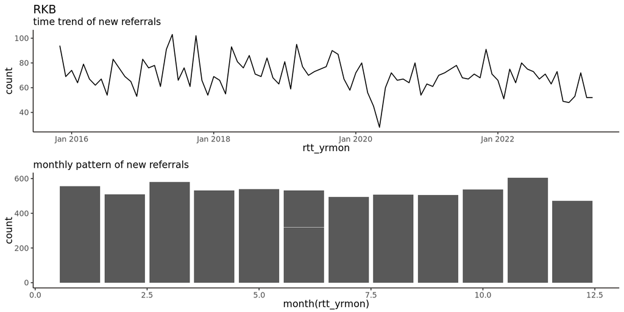

```r
fn_plots("RKB")
```

## What if we want more than one argument?

Easy! Just add them to the arguments when you define the function.

If I wanted to run this function on multiple dataframes I would change the function to:

```r
fn_plots <- function(df, prov){

    p1 <- df |>
      filter(provider_code == prov)
    # and the rest as before
}
```

and run it with `fn_plots(new_rtt, "RKB")`.

Note that the order of entering the parameters is important. If I tried to run `fn_plots("RKB", new_rtt)` it would look for a dataframe called `"RKB"` and a provider called `new_rtt`.

## Working through a list of parameters

Avoid manually running `fn_plots()` for each provider.  
Use `purrr::map` to iterate over a list

[figure not shown]

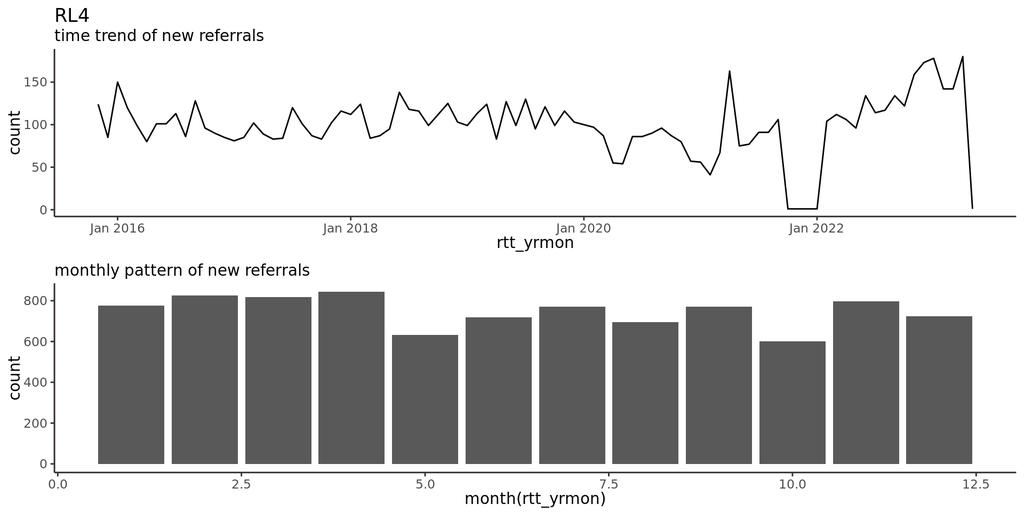

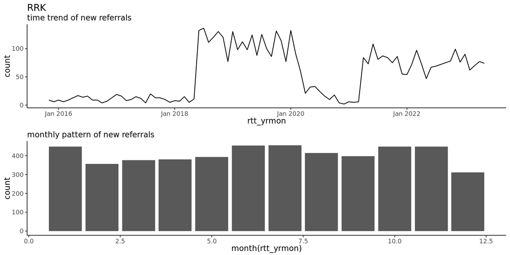

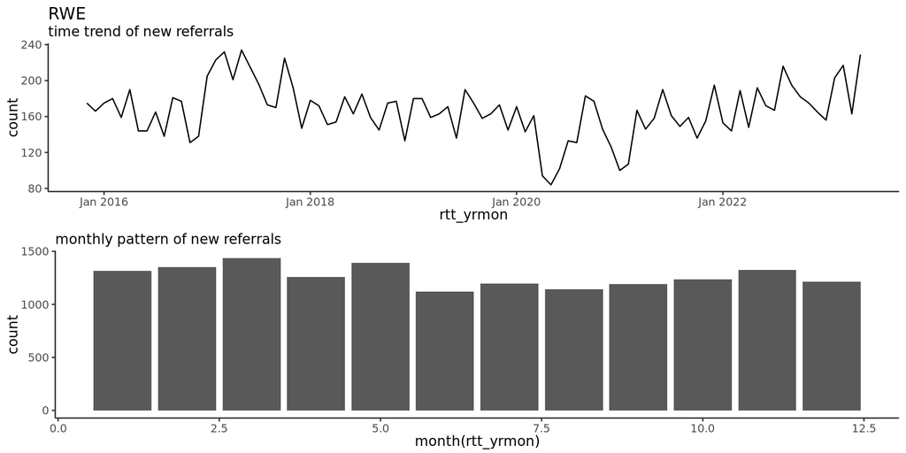

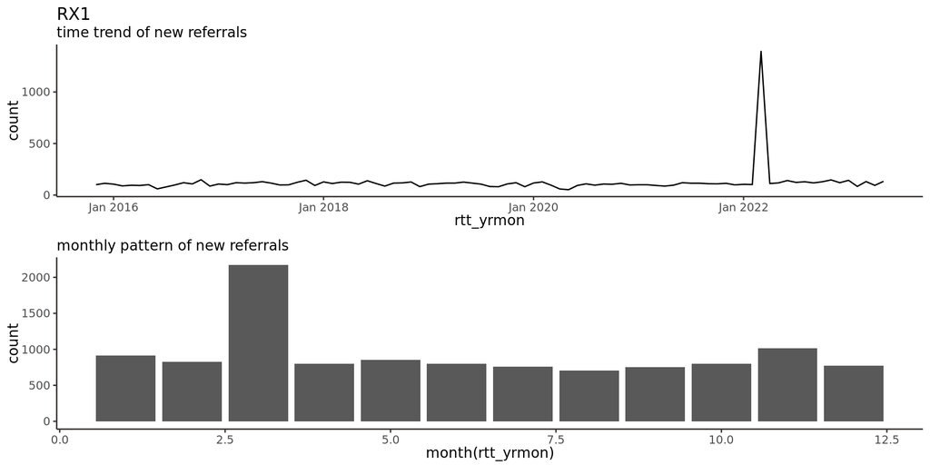

```r
# create a vector of all the providers
prov_labels <- c("RJE", "RKB", "RL4", "RRK", "RWE", "RX1")

map(prov_labels, ~ fn_plots(.x))
```

## Troubleshooting - does the function work?

Crawl before you can walk - make sure `fn_plot()` works for one parameter.

Insert `browser()` into the function while testing - steps into the function (don’t forget to remove it when it works!)

```r
fn_save_plot <- function(prov){

    p <- new_rtt |>
      filter(provider_code == prov) |>
      ggplot(aes(x = month(rtt_yrmon), y = count)) +
      geom_col() +
      su_theme() +
        theme(legend.position = "none") +
      labs(
           subtitle = paste0(prov, " - monthly pattern of new referrals"))

    ggsave(paste0(prov, "_plot.png"),
           plot = p)

}
```

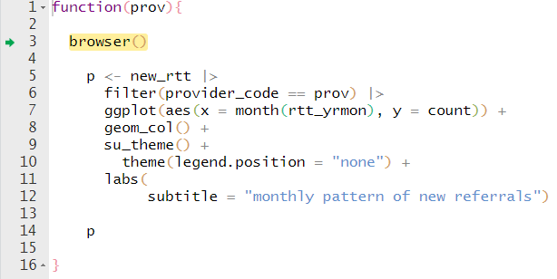

[figure not shown]

Check out [Shannon Pileggi’s slides](https://shannonpileggi.github.io/debugging-nhsr) for more options

## Troubleshooting - does it walk the walk?

When learning to walk, use `safely()` or `possibly()` in your `walk` function - it will indicate if any parameters have failed, rather than just fall down.

```r
# wrap fn_plots in safely
safe_pl <- safely(.f = fn_save_plot)

map(prov_labels, ~ safe_pl(.x))


# wrap fn_plots in possibly
poss_pl <- possibly(.f = fn_save_plot)

map(prov_labels, ~ poss_pl(.x))
```

Console output of wrapping function in `possibly`

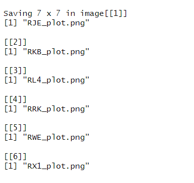

This is my first attempt at a Quarto presentation!